# SHRS Market Analysis — 2024 Labor Force Size & Growth (Table 3.1)

SHRS MQE Capstone Team

2026-02-14

```r
library(tidyverse); library(scales); library(knitr); library(kableExtra)
```

# 0 — Configuration

```r
VINTAGE <- "2024"
YR1 <- 2004; YR2 <- 2014; YR3 <- 2024; YR4 <- 2034
PROJ_LABEL <- paste0(YR3, "-", YR4)

CSV_PATH <- file.path(path.expand("~"), "Documents", "SHRS_Analysis",
                       "market_analysis", "v3data", "projections_csv",
                       "labor_force_csv", VINTAGE,
                       paste0("labor-force_", VINTAGE, " - Table 3.1.csv"))

signal_colors <- c("Green"="#27ae60","Yellow"="#f39c12","Red"="#e74c3c")
```

# 1 — Load & Clean

Table 3.1: Labor force levels (thousands), changes, percent changes, percent distributions, and compound annual growth rates by demographic group.

```r
raw <- read_csv(CSV_PATH, show_col_types = FALSE)

# 18 columns: Group + 4 levels + 3 changes + 3 pct changes + 4 distributions + 3 CAGRs
names(raw) <- c("group",
                "lf_yr1","lf_yr2","lf_yr3","lf_yr4",
                "chg_12","chg_23","chg_34",
                "pct_chg_12","pct_chg_23","pct_chg_34",
                "dist_yr1","dist_yr2","dist_yr3","dist_yr4",
                "cagr_12","cagr_23","cagr_34")

clean_num <- function(x) {
  x <- str_remove_all(as.character(x), ",")
  x[x %in% c("—","–","-","NA","")] <- NA
  suppressWarnings(as.numeric(x))
}

raw <- raw |>
  mutate(group = str_trim(group)) |>
  filter(group != "", !is.na(group)) |>
  mutate(across(-group, clean_num))
```

```r
cat(paste0("**Vintage:** ", VINTAGE, " | **Projection:** ", PROJ_LABEL,
           " | **Rows:** ", nrow(raw), "\n"))
```

**Vintage:** 2024 | **Projection:** 2024-2034 | **Rows:** 57

# 2 — Total Labor Force Overview

```r
total <- raw |> filter(str_detect(group, "^Total"))

tibble(
  Metric = c(paste0("LF ",YR1," (000s)"), paste0("LF ",YR2," (000s)"),
             paste0("LF ",YR3," (000s)"), paste0("LF ",YR4," projected (000s)"),
             paste0("Growth ",YR1,"-",YR2," (%)"), paste0("Growth ",YR2,"-",YR3," (%)"),
             paste0("Growth ",YR3,"-",YR4," (%)"), paste0("CAGR ",YR3,"-",YR4," (%)")),
  Value = c(total$lf_yr1, total$lf_yr2, total$lf_yr3, total$lf_yr4,
            total$pct_chg_12, total$pct_chg_23, total$pct_chg_34, total$cagr_34)
) |>
  mutate(Value = ifelse(abs(Value)>100, format(Value, big.mark=","), as.character(round(Value,1)))) |>
  kable(caption = "Total Labor Force Summary") |>
  kable_styling(bootstrap_options=c("striped","hover"), full_width=FALSE)
```

Total Labor Force Summary

| Metric | Value |
| --- | --- |
| LF 2004 (000s) | 147,402.0 |
| LF 2014 (000s) | 155,922.0 |
| LF 2024 (000s) | 168,104.0 |
| LF 2034 projected (000s) | 173,454.0 |
| Growth 2004-2014 (%) | 5.8 |
| Growth 2014-2024 (%) | 7.8 |
| Growth 2024-2034 (%) | 3.2 |
| CAGR 2024-2034 (%) | 0.3 |

```r
# Store key benchmarks
lf_growth_pct <- total$pct_chg_34
lf_cagr       <- total$cagr_34
lf_current    <- total$lf_yr3
lf_projected  <- total$lf_yr4
```

# 3 — Growth Deceleration Trend

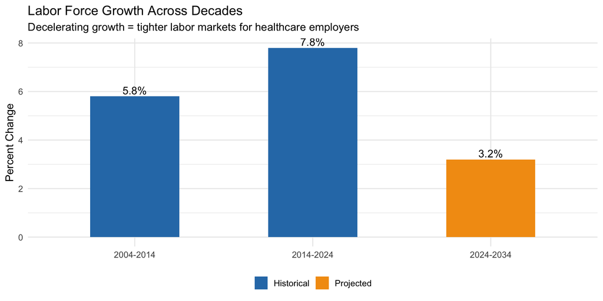

```r
tibble(
  Period = factor(c(paste0(YR1,"-",YR2), paste0(YR2,"-",YR3), paste0(YR3,"-",YR4)),
                  levels = c(paste0(YR1,"-",YR2), paste0(YR2,"-",YR3), paste0(YR3,"-",YR4))),
  Growth = c(total$pct_chg_12, total$pct_chg_23, total$pct_chg_34),
  Type = c("Historical","Historical","Projected")
) |>
  ggplot(aes(x=Period, y=Growth, fill=Type)) +
  geom_col(width=0.5) +
  geom_text(aes(label=paste0(Growth,"%")), vjust=-0.3, size=4.5) +
  scale_fill_manual(values=c("Historical"="#2c7bb6","Projected"="#f39c12")) +
  labs(title="Labor Force Growth Across Decades",
       subtitle="Decelerating growth = tighter labor markets for healthcare employers",
       x=NULL, y="Percent Change", fill=NULL) +
  theme_minimal(base_size=13) + theme(legend.position="bottom")
```

# 4 — Demographic Composition

## 4.1 Gender

```r
gender <- raw |> filter(str_detect(group, "^Men, 16|^Women, 16"))

gender |>
  select(Group=group, !!paste0("LF ",YR3):=lf_yr3, !!paste0("LF ",YR4):=lf_yr4,
         `Growth (%)`=pct_chg_34, !!paste0("Share ",YR3):=dist_yr3,
         !!paste0("Share ",YR4):=dist_yr4) |>
  kable(digits=1, caption="Labor Force by Gender") |>
  kable_styling(bootstrap_options=c("striped","hover"), full_width=FALSE)
```

Labor Force by Gender

| Group | LF 2024 | LF 2034 | Growth (%) | Share 2024 | Share 2034 |
| --- | --- | --- | --- | --- | --- |
| Men, 16 years and older | 88974 | 90969 | 2.2 | 52.9 | 52.4 |
| Women, 16 years and older | 79130 | 82485 | 4.2 | 47.1 | 47.6 |

## 4.2 Race/Ethnicity

```r
race <- raw |>
  filter(str_detect(group, "^White,|^Black,|^Asian,|^Hispanic origin,"))

race |>
  select(Group=group, !!paste0("LF ",YR3," (K)"):=lf_yr3, `Growth (%)`=pct_chg_34,
         !!paste0("Share ",YR3):=dist_yr3, !!paste0("Share ",YR4):=dist_yr4) |>
  kable(digits=1, caption="Labor Force by Race/Ethnicity") |>
  kable_styling(bootstrap_options=c("striped","hover"), full_width=FALSE)
```

Labor Force by Race/Ethnicity

| Group | LF 2024 (K) | Growth (%) | Share 2024 | Share 2034 |
| --- | --- | --- | --- | --- |
| White,16 years and older | 127634 | -0.3 | 75.9 | 73.4 |
| Black,16 years and older | 22047 | 7.6 | 13.1 | 13.7 |
| Hispanic origin,16 years and older | 32889 | 18.5 | 19.6 | 22.5 |

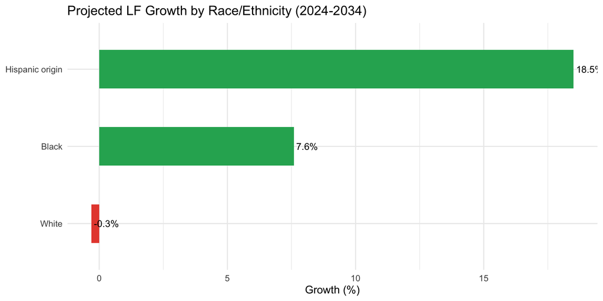

```r
race |>
  mutate(group = str_remove(group, ",.*")) |>
  ggplot(aes(x=reorder(group, pct_chg_34), y=pct_chg_34, fill=pct_chg_34>0)) +
  geom_col(width=0.5) +
  geom_text(aes(label=paste0(pct_chg_34,"%")), hjust=-0.1, size=4) +
  coord_flip() +
  scale_fill_manual(values=c("TRUE"="#27ae60","FALSE"="#e74c3c"), guide="none") +
  labs(title=paste0("Projected LF Growth by Race/Ethnicity (",PROJ_LABEL,")"),
       x=NULL, y="Growth (%)") +
  theme_minimal(base_size=13)
```

## 4.3 Age Structure

```r
# Extract age rows (indented or starting with digit)
age <- raw |>
  filter(str_detect(group, "^\\s*\\d+\\s+to\\s+\\d+|^\\s*55 and|^\\s*65 and|^\\s*75 and")) |>
  mutate(group = str_trim(group))

if (nrow(age) > 0) {
  age |>
    ggplot(aes(x=reorder(group, lf_yr3), y=lf_yr3)) +
    geom_col(fill="#2c7bb6", width=0.6) +
    geom_text(aes(label=format(lf_yr3, big.mark=",")), hjust=-0.1, size=3) +
    coord_flip() +
    labs(title=paste0("Labor Force by Age Group (",YR3,", thousands)"),
         x=NULL, y="Labor Force (thousands)") +
    theme_minimal(base_size=12)

  age |>
    select(Age=group, !!paste0("LF ",YR3):=lf_yr3, !!paste0("LF ",YR4):=lf_yr4,
           `Growth (%)`=pct_chg_34) |>
    kable(digits=1, caption="Age Group Projections") |>
    kable_styling(bootstrap_options=c("striped","hover"), full_width=FALSE)
}
```

Age Group Projections

| Age | LF 2024 | LF 2034 | Growth (%) |
| --- | --- | --- | --- |
| 16 to 24 | 21777 | 19649 | -9.8 |
| 16 to 19 | 6484 | 5687 | -12.3 |
| 20 to 24 | 15293 | 13962 | -8.7 |
| 25 to 54 | 107521 | 112929 | 5.0 |
| 25 to 34 | 37181 | 38046 | 2.3 |
| 35 to 44 | 37403 | 39116 | 4.6 |
| 45 to 54 | 32937 | 35768 | 8.6 |
| 55 and older | 38806 | 40876 | 5.3 |
| 55 to 64 | 27166 | 26324 | -3.1 |
| 65 to 74 | 9509 | 10933 | 15.0 |
| 75 and older | 2131 | 3618 | 69.8 |
| 16 to 24 | 11078 | 9782 | -11.7 |
| 16 to 19 | 3253 | 2849 | -12.4 |
| 20 to 24 | 7825 | 6933 | -11.4 |
| 25 to 54 | 57097 | 59502 | 4.2 |
| 25 to 34 | 19753 | 19784 | 0.2 |
| 35 to 44 | 19943 | 20783 | 4.2 |
| 45 to 54 | 17401 | 18935 | 8.8 |
| 55 and older | 20799 | 21685 | 4.3 |
| 55 to 64 | 14438 | 13869 | -3.9 |
| 65 to 74 | 5141 | 5798 | 12.8 |
| 75 and older | 1220 | 2018 | 65.4 |
| 16 to 24 | 10699 | 9867 | -7.8 |
| 16 to 19 | 3231 | 2838 | -12.2 |
| 20 to 24 | 7468 | 7029 | -5.9 |
| 25 to 54 | 50424 | 53427 | 6.0 |
| 25 to 34 | 17428 | 18261 | 4.8 |
| 35 to 44 | 17460 | 18332 | 5.0 |
| 45 to 54 | 15536 | 16833 | 8.3 |
| 55 and older | 18007 | 19191 | 6.6 |
| 55 to 64 | 12728 | 12456 | -2.1 |
| 65 to 74 | 4368 | 5135 | 17.6 |
| 75 and older | 911 | 1600 | 75.6 |

# 5 — Healthcare Workforce Implications

```r
cat(paste0("### Key Takeaways for SHRS Programs\n\n"))
```

### Key Takeaways for SHRS Programs

```r
cat(paste0("- <span style='color:#2c7bb6;'>**Total LF growth ",PROJ_LABEL,":**</span> ",
           lf_growth_pct, "% — substantially slower than prior decades\n"))
```

- **Total LF growth 2024-2034:** 3.2% — substantially slower than prior decades

```r
cat(paste0("- <span style='color:#2c7bb6;'>**Aging workforce:**</span> ",
           "Older age cohorts growing fastest while younger cohorts shrink — ",
           "increases demand for rehabilitation and health services\n"))
```

- **Aging workforce:** Older age cohorts growing fastest while younger cohorts shrink — increases demand for rehabilitation and health services

```r
hisp <- raw |> filter(str_detect(group, "^Hispanic origin"))
if (nrow(hisp)>0) {
  cat(paste0("- <span style='color:#2c7bb6;'>**Fastest-growing demographic:**</span> ",
             "Hispanic/Latino workers (", hisp$pct_chg_34, "% growth) — ",
             "implications for culturally competent care training\n"))
}
```

[output not shown]

```r
cat(paste0("- <span style='color:#2c7bb6;'>**Supply constraint signal:**</span> ",
           "Decelerating LF growth means tighter labor markets across all healthcare ",
           "professions — supports strong employment outlook for SHRS graduates\n"))
```

- **Supply constraint signal:** Decelerating LF growth means tighter labor markets across all healthcare professions — supports strong employment outlook for SHRS graduates

# 6 — Labor Force Growth Scorecard

How does projected LF growth contextualize SHRS program demand?

```r
lf_scorecard_2024 <- tibble(
  metric = c("Total LF Growth (%)", "CAGR (%)",
             "Current LF (millions)", "Projected LF (millions)"),
  value = c(lf_growth_pct, lf_cagr,
            round(lf_current/1000, 1), round(lf_projected/1000, 1)),
  signal = c(
    case_when(lf_growth_pct >= 5 ~ "Green", lf_growth_pct >= 2 ~ "Yellow", TRUE ~ "Red"),
    case_when(lf_cagr >= 0.5 ~ "Green", lf_cagr >= 0.2 ~ "Yellow", TRUE ~ "Red"),
    "—", "—"
  )
)

lf_scorecard_2024 |>
  kable(col.names=c("Metric","Value","Signal"), digits=1,
        caption=paste0("Labor Force Macro Scorecard (",VINTAGE,")")) |>
  kable_styling(bootstrap_options=c("striped","hover"), full_width=FALSE)
```

Labor Force Macro Scorecard (2024)

| Metric | Value | Signal |
| --- | --- | --- |
| Total LF Growth (%) | 3.2 | Yellow |
| CAGR (%) | 0.3 | Yellow |
| Current LF (millions) | 168.1 | — |
| Projected LF (millions) | 173.5 | — |

# 7 — Stored Outputs

```r
lf_t31_2024_raw       <- raw
lf_t31_2024_total     <- total
lf_t31_2024_gender    <- gender
lf_t31_2024_race      <- if(exists("race")) race else NULL
lf_t31_2024_age       <- if(exists("age")) age else NULL
lf_t31_2024_scorecard <- lf_scorecard_2024
lf_t31_2024_benchmarks <- list(
  growth_pct = lf_growth_pct, cagr = lf_cagr,
  current = lf_current, projected = lf_projected,
  yr3 = YR3, yr4 = YR4
)
```

```r
cat("| Variable | Description |\n|---|---|\n")
```

| Variable | Description |
| --- | --- |

```r
cat(paste0("| `lf_t31_2024_raw` | Full T3.1 data (",nrow(raw)," rows) |\n"))
```

`lf_t31_2024_raw` | Full T3.1 data (57 rows) |

```r
cat("| `lf_t31_2024_total` | Total LF row |\n")
```

`lf_t31_2024_total` | Total LF row |

```r
cat("| `lf_t31_2024_gender` | Gender breakdown |\n")
```

`lf_t31_2024_gender` | Gender breakdown |

```r
cat("| `lf_t31_2024_race` | Race/ethnicity breakdown |\n")
```

`lf_t31_2024_race` | Race/ethnicity breakdown |

```r
cat("| `lf_t31_2024_age` | Age group breakdown |\n")
```

`lf_t31_2024_age` | Age group breakdown |

```r
cat("| `lf_t31_2024_scorecard` | Macro scorecard |\n")
```

`lf_t31_2024_scorecard` | Macro scorecard |

```r
cat("| `lf_t31_2024_benchmarks` | Key benchmark list (growth, CAGR, levels) |\n")
```

`lf_t31_2024_benchmarks` | Key benchmark list (growth, CAGR, levels) |

**Source:** BLS Table 3.1, 2024 vintage. Projection period: 2024–2034.